# R Notebook

```r
library( tidyverse )
```

```r
source( "~/Script repository/R scripting/Matrix_Fns.R" ) #5/2/23 commit at my github https://github.com/McK-Ford/Script-repository/blob/main/R%20scripting/Matrix.R
```

```r
mygenes <- fread(
  file = "C:/Users/kayle/Box/Vertinolab/McKayla Ford/Projects/R-loops_Pausing/Sequence_based_analysis/Classing_by_Skew/beds/skew_classed_refseq_wheader.txt"
  )
```

Bed filtering 1

```r
gene_info_p <- mygenes |> filter( strand == "+" & chrom != "chrX" & gene_l > 150 )
gene_info_m <- mygenes |> filter( strand == "-" & chrom != "chrX" & gene_l > 150 )
```

For TSS regions (to get pause index, tss regions divided by gene body regions…) this isnt’ actually prox dist, names are wrong

```r
TSS_p <- gene_info_p |>
  select( c( "chrom", "gene_s", "cpg_e", "uniq_id", "TSS_skew", "strand" ) )
TSS_m <- gene_info_m |>
  select( c( "chrom",  "cpg_s", "gene_e", "uniq_id", "TSS_skew", "strand" ) )

colnames( TSS_p ) <- c(
    "chrom",
    "start",
    "end",
    "uniq_id",
    "score",
    "strand"
    )
colnames( TSS_m ) <- c(
    "chrom",
    "start",
    "end",
    "uniq_id",
    "score",
    "strand"
    )
```

```r
TSS_p$end <- TSS_p$start + 100
TSS_m$start <- TSS_m$end - 100
```

```r
DIR <- "C:/Users/kayle/Box/Vertinolab/McKayla Ford/Data/NascentSeq/PublicData/GSE156400_Fang_2021_HEK293T_PROseq_Rloops/Pro-seq/20211207 realigned/"
```

```r
gene_tab <- rbind(TSS_p, TSS_m)

bamscore <- score_matrix(
      bed = gene_tab,
      readsource = paste0(
    DIR,
    "bam/Liang_hek_proseq_2021_1.bam"
    ),
      n = 1,
      ignorestrand = FALSE,
      sbp=TRUE,
      revcomp=TRUE,
      method = "bi_anch",
      bam_or_bw = "bam",
    rnorm = FALSE
      )
```

For gene body

```r
body_p <- gene_info_p |>
  select( c( "chrom", "gene_s", "gene_e", "uniq_id", "TSS_skew", "strand" ) )
body_m <- gene_info_m |>
  select( c( "chrom",  "gene_s", "gene_e", "uniq_id", "TSS_skew", "strand" ) )

colnames( body_p ) <- c(
    "chrom",
    "start",
    "end",
    "uniq_id",
    "score",
    "strand"
    )
colnames( body_m ) <- c(
    "chrom",
    "start",
    "end",
    "uniq_id",
    "score",
    "strand"
    )

body_p$start <- body_p$start + 100
body_m$end <- body_m$end - 100

body_tab <- rbind(body_p, body_m)
```

```r
bambodyscore <- score_matrix(
      bed = body_tab,
      readsource = paste0(
    DIR,
    "bam/Liang_hek_proseq_2021_1.bam"
    ),
      n = 1,
      ignorestrand = FALSE,
      sbp=TRUE,
      revcomp=TRUE,
      method = "bi_anch",
      bam_or_bw = "bam"
      )

# plusbodyscore <- score_matrix(
#       bed = body_p,
#       readsource = paste0(
#     DIR,
#     "bw/Liang_hek_proseq_2021_1_fwd_nodedup.bw"
#     ),
#       n = 1,
#       ignorestrand = TRUE, #already filtered to plus minus, ignore strand false is more for bam files
#       method = "bi_anch",
#       bam_or_bw = "bw"
#       )
# minusbodyscore <- score_matrix(
#       bed = body_m,
#       readsource = paste0(
#     DIR,
#     "bw/Liang_hek_proseq_2021_1_rev_nodedup.bw"
#     ),
#       n = 1,
#       ignorestrand = TRUE,
#       method = "bi_anch",
#       bam_or_bw = "bw"
#       )
```

Alright. Now to get values.

They are in identical order, so it is safe to join them by merging them. Unfortunately they’re data tables not frames at the moment which I think is why this is being tempramental right now..

```r
bamscore <- as.data.frame(bamscore)
bambodyscore <- as.data.frame(bambodyscore)

bam_scores <- cbind(bamscore[1], bamscore[7], bambodyscore[7])
colnames(bam_scores) <- c("uniq_id", "tss_score", "body_score")
```

There we go, for some reason it didn’t like double brackets today. As they are already normalized to bin size I can just divide one by the other.

```r
bam_scores$idx <- bam_scores$tss_score / bam_scores$body_score
```

```r
gene_info <- rbind(gene_info_p, gene_info_m)
parenttab <- merge(gene_info, bam_scores, by = "uniq_id")
```

Now we need to filter out the lowest gene body scores so we don’t have falsely inflated indices.

```r
summary(parenttab$body_score) #remember, this is essentially 'reads per base pair' so of course they're low. Let's say 1 read per 10 kb?
```

```
     Min.   1st Qu.    Median      Mean
0.0000000 0.0001136 0.0005919 0.0038929
  3rd Qu.      Max.
0.0023662 1.3239107
```

```r
ecdf(parenttab$body_score)(0.0001)
```

```
[1] 0.2371602
```

About 24% of the data falls below that threshold. Is that reasonable?

```r
quantile(parenttab$body_score, 0.05)
```

```
          5%
1.568819e-06
```

Probably more reasonable than a 1 read per million bp standard. Can always try with a less stringent filter though to see if it matters.

```r
distal <- parenttab |> filter(simple_skew_class == "Dist" & body_score > 0.0001)
proximal <- parenttab |> filter(simple_skew_class == "Prox" & body_score > 0.0001)
```

```r
test = wilcox.test(x = proximal$idx, y = distal$idx, paired = FALSE,
            conf.int = TRUE, correct = FALSE)
test
```

```
    Wilcoxon rank sum test

data:  proximal$idx and distal$idx
W = 13075275, p-value = 1.244e-09
alternative hypothesis: true location shift is not equal to 0
95 percent confidence interval:
 129.6179 285.8377
sample estimates:
difference in location
              205.0919
```

Okay, so p value does indicate there is a proximal/distal shift.

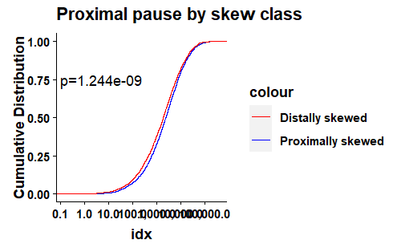

```r
source("~/Script repository/R scripting/Graphing_Functions.R")
skew_colors <- c("Proximally skewed" = "blue", "Distally skewed" = "red")
 ggplot() +
  stat_ecdf(geom="step", data=proximal, aes(idx, color = "Proximally skewed")) +
  stat_ecdf(geom="step", data=distal, aes(idx, color = "Distally skewed")) +
  mytheme +
  scale_x_log10(n.breaks=6, labels=scales::label_comma()) +
   ggtitle("Proximal pause by skew class") +
  scale_color_manual(values = skew_colors) +
  ylab("Cumulative Distribution") +
  annotate("text", x = 5, y = 0.75, label = paste0("p=", signif(test$p.value, digits = 4)))
```